# Analysis Example 4: Cross-sectional multi-level

# Overview

Each of these pages provides an analysis run through for a different type of design. Each document is structured in the same way. First the data is introduced. For the purpose of these tutorials, I will only use examples where the data can be shared - either because it is from an open access publication, or because it is unpublished or simulated. Second, the structure of the data is discussed so that we can more easily see what data structure the design creates, and how this aligns to the variables in the data. Third, we translate the research questions into formal equations, and then `lmer()` code. Finally, we will follow those through for our example data.

# Ex.4: Cross-sectional Multi-level

## Data structure

OK, in this example we are keeping with my home territory of organisational psychology. This data set was provided by Dr. David Hughes, from Manchester Business School. It is a subset of a larger data set that has been published on.

- OrgID: organisation ID
- Sex: 0= female, 1=male
- Mot: self-rated motivation
- Perf: boss rated performance
- PubPri: 0= public, 1=private
- Region: geographical location, 1=Wales, 2=England, 3=Scotland
- Size: number of employees 1= <20, 2=21-50, 3=50-100, 4=100-250, 5=251-500, 6=500-1,000, 7=1,000+

# Model specification

Here we are going to be looking at predicting employee performance from self-motivation, and investigating whether this effect is consistent across organisation. We will also look at whether the fact an organisation is public or private accounts for variation in model intercepts and slopes.

# Analysis

## Tidy data

This data set is available on LEARN. Remember to change your file path.

```r
library(tidyverse)
perform <- read_csv("C:/Multi/Analysis Examples/Data/MLM_Org.csv")
perform %>%
  filter(OrgID == "Org1")
```

| OrgID | Sex | Mot | Perform | PubPri | Region | Size |
| --- | --- | --- | --- | --- | --- | --- |
| Org1 | female | 3 | 58 | public | England | 3 |
| Org1 | female | 7 | 59 | public | England | 3 |
| Org1 | male | 4 | 60 | public | England | 3 |
| Org1 | male | 1 | 48 | public | England | 3 |
| Org1 | female | 4 | 59 | public | England | 3 |
| Org1 | male | 4 | 50 | public | England | 3 |
| Org1 | female | 1 | 43 | public | England | 3 |
| Org1 | female | 2 | 48 | public | England | 3 |
| Org1 | male | 5 | 65 | public | England | 3 |
| Org1 | male | 2 | 41 | public | England | 3 |

[output cut: 2 more lines]

Here we can see the first 10 employees in `Org1`. Look here at the values that are constant across the organisation, and those that vary by person.

## Describe

Given our data structure, it likely makes most sense for us to look at the averages across organisations.

```r
summary <-
  perform%>%
  group_by(OrgID) %>%
  summarise(
    N = n_distinct(Perform),
    Mean.Perf = round(mean(Perform, na.rm=T),2),
    SD.Perf = round(sd(Perform, na.rm=T),2),
    Mean.Motiv = round(mean(Mot, na.rm=T),2),
    SD.Motiv = round(sd(Mot, na.rm=T),2)
    )
```

```r
library(kableExtra)
kable(summary) %>%
  kable_styling("striped")
```

| OrgID | N | Mean.Perf | SD.Perf | Mean.Motiv | SD.Motiv |
| --- | --- | --- | --- | --- | --- |
| Org1 | 9 | 53.75 | 8.07 | 3.08 | 1.78 |
| Org10 | 17 | 48.35 | 10.96 | 2.00 | 1.38 |
| Org11 | 17 | 43.55 | 10.01 | 1.64 | 1.50 |
| Org12 | 16 | 49.86 | 8.44 | 0.86 | 0.77 |
| Org13 | 12 | 46.40 | 4.32 | 1.15 | 0.81 |
| Org14 | 13 | 56.38 | 9.35 | 2.62 | 1.75 |
| Org15 | 16 | 55.70 | 9.53 | 1.83 | 1.23 |
| Org16 | 15 | 51.05 | 10.27 | 2.75 | 1.71 |
| Org17 | 11 | 40.95 | 6.36 | 1.63 | 1.07 |
| Org18 | 20 | 62.82 | 5.68 | 3.30 | 1.72 |
| Org19 | 16 | 49.67 | 10.34 | 2.10 | 1.14 |
| Org2 | 7 | 57.38 | 9.98 | 0.75 | 1.04 |
| Org20 | 14 | 46.33 | 9.55 | 1.33 | 0.91 |
| Org21 | 17 | 51.33 | 9.99 | 1.63 | 1.08 |
| Org22 | 14 | 47.85 | 11.30 | 1.60 | 1.43 |
| Org23 | 12 | 54.93 | 12.47 | 2.00 | 1.75 |
| Org3 | 4 | 56.60 | 11.84 | 2.20 | 1.64 |
| Org4 | 16 | 48.46 | 8.62 | 1.50 | 0.98 |
| Org5 | 17 | 45.74 | 7.53 | 1.39 | 1.12 |
| Org6 | 14 | 53.94 | 7.30 | 1.76 | 1.20 |
| Org7 | 16 | 50.09 | 9.14 | 1.50 | 1.01 |
| Org8 | 15 | 42.15 | 8.32 | 2.35 | 1.31 |
| Org9 | 20 | 53.25 | 11.52 | 1.83 | 1.13 |

Note the different numbers of employees we have across organisation. Clearly this will mean the information provided by each organisation will vary.

## Visualize

Next, we can visualise the relationship between motivation and performance within each organisation.

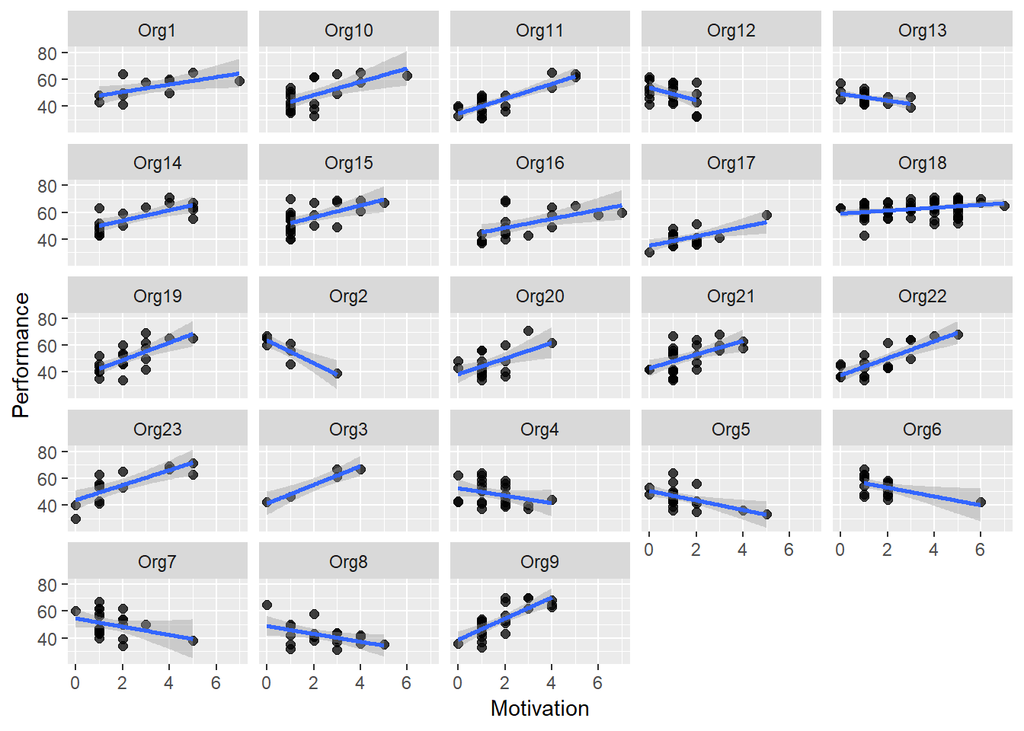

```r
perform %>%
  ggplot(aes(x=Mot, y=Perform, group = OrgID)) +
  geom_point(size = 2, alpha= .75) +
  geom_smooth(method = "lm") +
  labs(x="Motivation", y="Performance") +
  facet_wrap(~OrgID)
```

What we see here is A LOT of variability. Not only do the intercepts change, so does the steepness and direction of the slopes.

## Run models

As we have in many of our examples, let’s run an empty model, and look at the ICC for the grouping variable organisation.

```r
library(lme4)
# Empty model
m0 <- lmer(Perform ~ 1 +
             (1 | OrgID),
           data = perform)
summary(m0)
```

```
## Linear mixed model fit by REML ['lmerMod']
## Formula: Perform ~ 1 + (1 | OrgID)
##    Data: perform
##
## REML criterion at convergence: 3560
##
## Scaled residuals:
##      Min       1Q   Median       3Q      Max
## -2.69138 -0.71156 -0.03565  0.73487  2.68864
##
## Random effects:
##  Groups   Name        Variance Std.Dev.
##  OrgID    (Intercept) 25.05    5.005
##  Residual             80.34    8.964
## Number of obs: 487, groups:  OrgID, 23
##
## Fixed effects:
##             Estimate Std. Error t value
## (Intercept)   50.613      1.134   44.64
```

```r
# ICC
varM0 <- as.data.frame(VarCorr(m0))
varM0
```

| grp | var1 | var2 | vcov | sdcor |
| --- | --- | --- | --- | --- |
| OrgID | (Intercept) | NA | 25.05319 | 5.005316 |
| Residual | NA | NA | 80.34482 | 8.963527 |

```r
round((varM0[1,4]/sum(varM0[,4]))*100,2)
```

```
## [1] 23.77
```

So, around 24% of the variance in our data is at the grouping level, being around 76% is at the person level. So clearly we have scope here for explanatory variables of both types.

To begin, we add motivation as a fixed effect:

```r
# Fixed effect for motivation
m1 <- lmer(Perform ~ 1 + Mot +
             (1 | OrgID),
           data = perform)
summary(m1)
```

```
## Linear mixed model fit by REML ['lmerMod']
## Formula: Perform ~ 1 + Mot + (1 | OrgID)
##    Data: perform
##
## REML criterion at convergence: 3493
##
## Scaled residuals:
##     Min      1Q  Median      3Q     Max
## -2.6341 -0.6969 -0.0137  0.6438  3.2444
##
## Random effects:
##  Groups   Name        Variance Std.Dev.
##  OrgID    (Intercept) 20.30    4.506
##  Residual             70.25    8.381
## Number of obs: 487, groups:  OrgID, 23
##
## Fixed effects:
##             Estimate Std. Error t value
## (Intercept)   46.035      1.159  39.731
## Mot            2.453      0.288   8.517
##
## Correlation of Fixed Effects:
##     (Intr)
## Mot -0.464
```

From this, we can calculate the reduction in the residual variance, or the PRV:

```r
# PRV - how much residual variance does motivation account for
m1_sum <- summary(m1)
varM1 <- as.data.frame(m1_sum$varcor)
varM1
```

| grp | var1 | var2 | vcov | sdcor |
| --- | --- | --- | --- | --- |
| OrgID | (Intercept) | NA | 20.30283 | 4.505866 |
| Residual | NA | NA | 70.24540 | 8.381253 |

```r
round(((varM0[2,4]-varM1[2,4])/varM0[2,4])*100,2)
```

```
## [1] 12.57
```

Not bad, so there is a 12.5% reduction in level 1 residula variance from the inclusion of motivation. The coefficient is positive, which is what we would hope to see, motivated employees have better performance.

We will do all of our model comparisons in one go at the end of our model building, so let’s continue. Next, is a random slope (as evidenced by our plots above) for motivation.

```r
# Random slope
m2 <- lmer(Perform ~ 1 + Mot +
             (1 + Mot | OrgID),
           data = perform)
summary(m2)
```

```
## Linear mixed model fit by REML ['lmerMod']
## Formula: Perform ~ 1 + Mot + (1 + Mot | OrgID)
##    Data: perform
##
## REML criterion at convergence: 3393.7
##
## Scaled residuals:
##      Min       1Q   Median       3Q      Max
## -2.27285 -0.69631 -0.00381  0.66059  2.82122
##
## Random effects:
##  Groups   Name        Variance Std.Dev. Corr
##  OrgID    (Intercept) 62.10    7.880
##           Mot         18.06    4.250    -0.84
##  Residual             50.88    7.133
## Number of obs: 487, groups:  OrgID, 23
##
## Fixed effects:
##             Estimate Std. Error t value
## (Intercept)  46.0257     1.7570  26.196
## Mot           2.0031     0.9351   2.142
##
## Correlation of Fixed Effects:
##     (Intr)
## Mot -0.834
```

And now we can look to compare the set of models before adding the predictors:

```r
anova(m0, m1, m2)
```

```
## refitting model(s) with ML (instead of REML)
```

|  | Df | AIC | BIC | logLik | deviance | Chisq | Chi Df | Pr(>Chisq) |
| --- | --- | --- | --- | --- | --- | --- | --- | --- |
| m0 | 3 | 3568.089 | 3580.654 | -1781.045 | 3562.089 | NA | NA | NA |
| m1 | 4 | 3502.195 | 3518.948 | -1747.098 | 3494.195 | 67.89424 | 1 | 1.725046e-16 |
| m2 | 6 | 3409.109 | 3434.238 | -1698.554 | 3397.109 | 97.08658 | 2 | 8.277829e-22 |

In each case, adding the additional parameters has improved our model, so we will keep them all.

## Predicting intercepts and slopes

Our big interest here is in whether organisations being public or private changes the relationship of motivation to performance. For this, we will want to include the cross level interaction beteen `Mot` and `PubPri`.

```r
m3 <- lmer(Perform ~ 1 + Mot + PubPri + Mot*PubPri +
             (1 + Mot | OrgID),
           data = perform)
summary(m3)
```

```
## Linear mixed model fit by REML ['lmerMod']
## Formula: Perform ~ 1 + Mot + PubPri + Mot * PubPri + (1 + Mot | OrgID)
##    Data: perform
##
## REML criterion at convergence: 3384.4
##
## Scaled residuals:
##      Min       1Q   Median       3Q      Max
## -2.29012 -0.69613 -0.02848  0.65620  2.76816
##
## Random effects:
##  Groups   Name        Variance Std.Dev. Corr
##  OrgID    (Intercept) 63.44    7.965
##           Mot         18.62    4.315    -0.86
##  Residual             50.91    7.135
## Number of obs: 487, groups:  OrgID, 23
##
## Fixed effects:
##                  Estimate Std. Error t value
## (Intercept)       45.2718     2.1765  20.800
## Mot                1.7909     1.1737   1.526
## PubPripublic       2.4448     3.7570   0.651
## Mot:PubPripublic   0.5623     1.9904   0.283
##
## Correlation of Fixed Effects:
##             (Intr) Mot    PbPrpb
## Mot         -0.853
## PubPripublc -0.579  0.494
## Mt:PbPrpblc  0.503 -0.590 -0.848
```

The *t*-values here are pretty small. This doesn’t look like the added effects have contributed much to our model.

```r
# model comparison
anova(m2,m3)
```

```
## refitting model(s) with ML (instead of REML)
```

|  | Df | AIC | BIC | logLik | deviance | Chisq | Chi Df | Pr(>Chisq) |
| --- | --- | --- | --- | --- | --- | --- | --- | --- |
| m2 | 6 | 3409.109 | 3434.238 | -1698.554 | 3397.109 | NA | NA | NA |
| m3 | 8 | 3410.118 | 3443.624 | -1697.059 | 3394.118 | 2.990829 | 2 | 0.2241557 |

And indeed our model comparison suggests not. But wait a minute, we forgot about something….

…we need to center our predictors.

```r
perform <-
  perform %>%
  mutate(
    Mot_c = Mot - mean(Mot, na.rm=T)
  )
```

And re-run the model:

```r
m4 <- lmer(Perform ~ 1 + Mot_c + PubPri + Mot_c*PubPri +
             (1 + Mot_c | OrgID),
           data = perform)
summary(m4)
```

```
## Linear mixed model fit by REML ['lmerMod']
## Formula: Perform ~ 1 + Mot_c + PubPri + Mot_c * PubPri + (1 + Mot_c |
##     OrgID)
##    Data: perform
##
## REML criterion at convergence: 3384.4
##
## Scaled residuals:
##      Min       1Q   Median       3Q      Max
## -2.29012 -0.69613 -0.02848  0.65620  2.76816
##
## Random effects:
##  Groups   Name        Variance Std.Dev. Corr
##  OrgID    (Intercept) 19.38    4.402
##           Mot_c       18.62    4.315    0.38
##  Residual             50.91    7.135
## Number of obs: 487, groups:  OrgID, 23
##
## Fixed effects:
##                    Estimate Std. Error t value
## (Intercept)         48.8057     1.2248  39.848
## Mot_c                1.7909     1.1737   1.526
## PubPripublic         3.5543     2.1281   1.670
## Mot_c:PubPripublic   0.5623     1.9904   0.283
##
## Correlation of Fixed Effects:
##             (Intr) Mot_c  PbPrpb
## Mot_c        0.375
## PubPripublc -0.576 -0.216
## Mt_c:PbPrpb -0.221 -0.590  0.349
```

What do you notice about the results? Spend a little bit of time comparing the effects (fixed and random) and see the changes that result from centering a variable.